# 431 Class 04

Thomas E. Love, Ph.D.

2025-09-11

## Today’s Agenda

- Analyzing some data from the 15-item Quick Survey.
- Addressing five exploratory questions.
- Demonstrate techniques and code that might be helpful for Lab 1, due next Wednesday 2025-09-17 at noon.

## Load packages and set theme

```r
library(janitor)
library(patchwork)
library(rstanarm)   ## new today
library(easystats)
library(tidyverse)

theme_set(theme_bw())
knitr::opts_chunk$set(comment = NA)

source("c04/data/Love-431.R") ## new today
```

We’re sourcing in the `Love-431.R` R script, which contains a function we’ll use.

## Ingest, manage data

Read in data from `.csv` (comma-separated version) file.

```r
surv15_raw <-
  read_csv("c04/data/survey15_2014_to_2025.csv",
           show_col_types = FALSE) |>
  janitor::clean_names()
```

Select variables, make categories into factors

```r
surv15 <- surv15_raw |>
    select(student, year, english, smoke, pulse, height_in, haircut) |>
    mutate(year = as_factor(year),
           smoke = as_factor(smoke),
           english = as_factor(english),
           student = as.character(student))
```

## Resulting tibble

```r
surv15
```

```
# A tibble: 656 × 7
   student year  english smoke pulse height_in haircut
   <chr>   <fct> <fct>   <fct> <dbl>     <dbl>   <dbl>
 1 202501  2025  n       1        96        63       0
 2 202502  2025  n       3        76        68      20
 3 202503  2025  y       1        72        75      20
 4 202504  2025  n       1        88        62       0
 5 202505  2025  n       1        64        64       0
 6 202506  2025  y       1        51        71       0
 7 202507  2025  y       3        72        67      50
 8 202508  2025  y       1        88        63       0
 9 202509  2025  n       1        68        68      25
10 202510  2025  n       3        92        71      32
# ℹ 646 more rows
```

## Five Exploratory Questions

1. What is the distribution of pulse rates among students in 431 since 2014?
2. Does the distribution of student heights change materially over time?
3. Is the Normal distribution a good model for student pulse rates from 2014-2025? How about haircut prices?
4. Do taller people appear to have paid less for their most recent haircut?
5. Do students have a more substantial tobacco history if their best language is English or something else?

# Question 1

## Question 1

What is the distribution of pulse rates among students in 431 since 2014?

```r
surv15 |> tabyl(pulse) |> adorn_pct_formatting()
```

```
 pulse  n percent valid_percent
    20  1    0.2%          0.2%
    30  1    0.2%          0.2%
    33  1    0.2%          0.2%
    44  1    0.2%          0.2%
    46  1    0.2%          0.2%
    48  4    0.6%          0.7%
    50  4    0.6%          0.7%
    51  1    0.2%          0.2%
    52  6    0.9%          1.0%
    54  6    0.9%          1.0%
    55  2    0.3%          0.3%
    56 13    2.0%          2.3%
    57  1    0.2%          0.2%
    58  5    0.8%          0.9%
```

[output cut: 43 more lines]

## Histogram, first try

- What is the distribution of student `pulse` rates?

```r
ggplot(data = surv15, aes(x = pulse)) +
    geom_histogram()
```

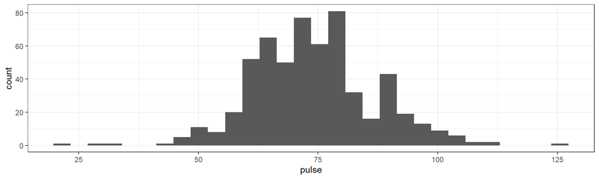

## Describing the Pulse Rates

How might we describe this distribution?

- What is the center?
- How much of a range around that center do we see? How spread out are the data?
- What is the shape of this distribution?
  - Is it symmetric, or is it skewed to the left or to the right?

(Histogram is re plotted on the next slide)

## Histogram (with warning suppressed)

```r
ggplot(data = surv15, aes(x = pulse)) +
    geom_histogram()
```

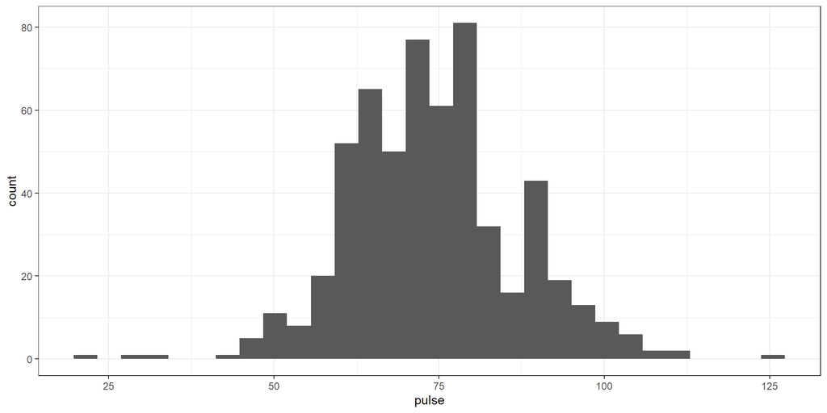

## Some Key Numerical Summaries

```r
surv15 |> select(pulse) |> summary()
```

```
     pulse
 Min.   : 20.00
 1st Qu.: 65.00
 Median : 72.00
 Mean   : 74.02
 3rd Qu.: 80.00
 Max.   :124.00
 NA's   :79
```

```r
length(surv15$pulse)
```

```
[1] 656
```

```r
sd(surv15$pulse, na.rm = TRUE)
```

```
[1] 12.69663
```

```r
mad(surv15$pulse, na.rm = TRUE)
```

```
[1] 11.8608
```

- Do these summaries help us describe the data?

## Histogram, version 2

```r
dat1 <- surv15 |>
  filter(complete.cases(pulse))

ggplot(data = dat1, aes(x = pulse)) +
    geom_histogram(fill = "seagreen", col = "white", bins = 20) +
    labs(title = "Pulse Rates of Dr. Love's students",
         subtitle = "2014 - 2025",
         y = "Number of Students",
         x = "Pulse Rate (beats per minute)")
```

- How did we deal with missing data?
- How did we add axis labels and titles to the plot?
- What is the distinction between `fill` and `col`?
- How many bins should we use?

## Histogram, version 2

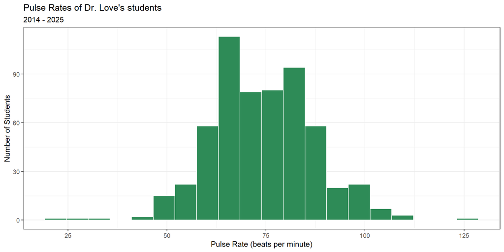

# Question 2

## Question 2

Does the distribution of student heights change over time?

```r
ggplot(surv15, aes(x = year, y = height_in)) +
  geom_point()
```

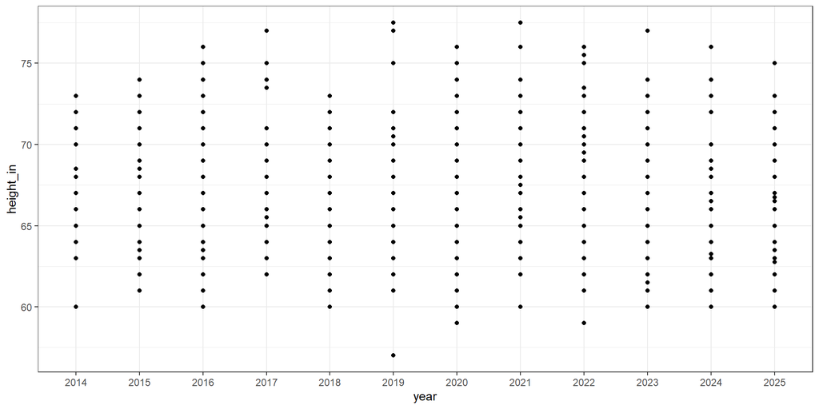

## Yearly Five-Number Summaries

```r
surv15 |>
    filter(complete.cases(height_in)) |>
    group_by(year) |>
    summarize(n = n(), min = min(height_in), q25 = quantile(height_in, 0.25),
              median = median(height_in), q75 = quantile(height_in, 0.75),
              max = max(height_in))
```

- What should this produce? (Results on next slide)

## Yearly Five-Number Summaries

```
# A tibble: 12 × 7
   year      n   min   q25 median   q75   max
   <fct> <int> <dbl> <dbl>  <dbl> <dbl> <dbl>
 1 2014     40    60  64.8   68    71    73
 2 2015     49    61  65     68    70    74
 3 2016     64    60  64     67    70    76
 4 2017     48    62  65     67    69    77
 5 2018     51    60  63     66    70    73
 6 2019     60    57  65     68    70    77.5
 7 2020     66    59  63     66    69.8  76
 8 2021     55    60  64.5   67.5  71    77.5
 9 2022     54    59  66     68.5  70.4  76
10 2023     53    60  64     65    69    77
11 2024     54    60  64     67    69.8  76
12 2025     53    60  63     66    68    75
```

- Do these summaries change materially over time?
- What are these summaries, specifically?

## Five-Number Summary

- Key summaries based on percentiles / quantiles
  - minimum = 0th, maximum = 100th, median = 50th
  - quartiles (25th, 50th and 75th percentiles)
  - Range is maximum - minimum
  - IQR (inter-quartile range) is 75th - 25th percentile
- These summaries are generally more resistant to outliers than mean, standard deviation
- Form the elements of a boxplot (box-and-whisker plot)

## Boxplot of Heights by Year

```r
dat1 <- surv15 |>
    filter(complete.cases(height_in))

ggplot(data = dat1, aes(x = year, y = height_in)) +
    geom_boxplot() +
    labs(title = "Heights of Dr. Love's students, by year",
         subtitle = "2014 - 2025", x = "Year", y = "Height (in inches)")
```

- How did we deal with missing data here?

## Boxplot of Heights by Year

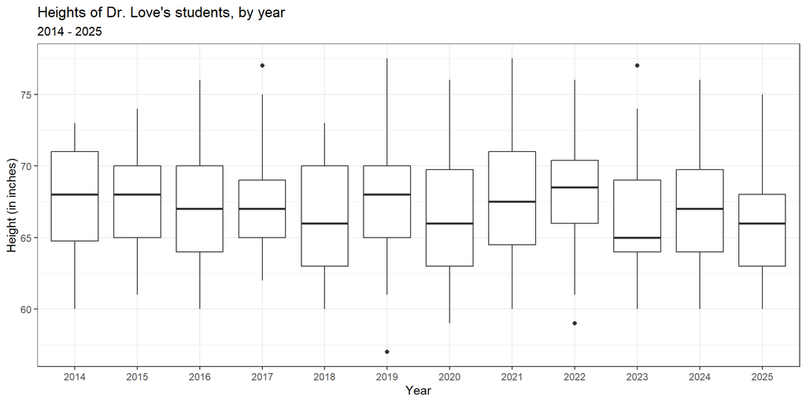

## Thinking about the Boxplot

- Box covers the middle half of the data (25th and 75th percentiles), and the solid line indicates the median
- Whiskers extend from the quartiles to the most extreme values that are not judged by **Tukey’s** “fences” method to be candidate outliers
  - Fences are drawn at 25th percentile - 1.5 IQR and 75th percentile + 1.5 IQR
- Are any values candidate outliers by this method?
- Was it important to change `year` to a factor earlier?

## Adding a Violin to the Boxplot

- When we’d like to better understand the shape of a distribution, we can amplify the boxplot.

```r
dat1 <- surv15 |>
    filter(complete.cases(height_in))

ggplot(data = dat1, aes(x = year, y = height_in)) +
    geom_violin() +
    geom_boxplot(aes(fill = year), width = 0.3) +
    guides(fill = "none") +
    scale_fill_viridis_d(alpha = 0.3) +
    labs(title = "Heights of Dr. Love's students, by year",
         subtitle = "2014 - 2025", x = "Year", y = "Height (in inches)")
```

## Adding a Violin to the Boxplot

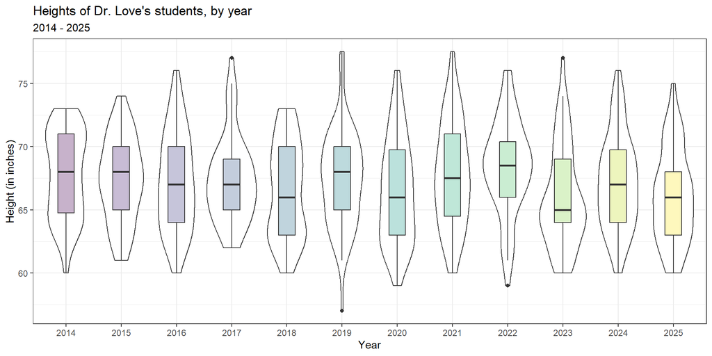

## Boxplot with Violin

- How did we change the boxplot when we added the violin?
- What would happen if we added the boxplot first and the violin second?
- What does `guides(fill = "none")` do?
- What does `scale_fill_viridis_d(alpha = 0.3)` do?

## Key Numerical Summaries

```r
surv15 |>
    filter(complete.cases(height_in)) |>
    group_by(year) |>
    summarize(n = n(), mean = mean(height_in), sd = sd(height_in),
              median = median(height_in), mad = mad(height_in))
```

```
# A tibble: 12 × 6
   year      n  mean    sd median   mad
   <fct> <int> <dbl> <dbl>  <dbl> <dbl>
 1 2014     40  67.8  3.46   68    4.45
 2 2015     49  67.3  3.32   68    2.97
 3 2016     64  67.2  3.86   67    4.45
 4 2017     48  67.4  3.46   67    2.97
 5 2018     51  66.5  3.81   66    4.45
 6 2019     60  67.4  3.83   68    4.45
 7 2020     66  66.4  4.09   66    4.45
 8 2021     55  67.8  4.13   67.5  5.19
 9 2022     54  68.4  3.74   68.5  3.71
10 2023     53  66.0  4.00   65    2.97
11 2024     54  67.2  3.70   67    4.45
12 2025     53  66.0  3.65   66    3.71
```

## Summary Statistics for Student Height, 2014-2025

```r
surv15 |> describe_distribution(height_in)
```

```
Variable  |  Mean |   SD | IQR |          Range | Skewness | Kurtosis |   n | n_Missing
---------------------------------------------------------------------------------------
height_in | 67.10 | 3.82 |   6 | [57.00, 77.50] |     0.21 |    -0.54 | 647 |         9
```

```r
surv15 |> describe_distribution(height_in, centrality = "median")
```

```
Variable  | Median |  MAD | IQR |          Range | Skewness | Kurtosis |   n | n_Missing
----------------------------------------------------------------------------------------
height_in |     67 | 4.45 |   6 | [57.00, 77.50] |     0.21 |    -0.54 | 647 |         9
```

## Use my `lovedist()` function from the `Love-431.R` script…

```r
surv15 |> reframe(lovedist(height_in)) |> print_md(digits = 2)
```

| n | miss | mean | sd | med | mad | min | q25 | q75 | max |
| --- | --- | --- | --- | --- | --- | --- | --- | --- | --- |
| 656 | 9 | 67.10 | 3.82 | 67 | 4.45 | 57 | 64 | 70 | 77.50 |

- n = sample size, miss = missing values
- mean = arithmetic average (sum of values / number of values)
- sd = standard deviation (measures dispersion)
- med = median (50th percentile)
- mad = median absolute deviation (scaled measure of dispersion)
- min, q25, q75, max = 0th, 25th, 75th and 100th percentile

## `lovedist()` results by year

```r
surv15 |> group_by(year) |> reframe(lovedist(height_in))
```

```
# A tibble: 12 × 11
   year      n  miss  mean    sd   med   mad   min   q25   q75   max
   <fct> <int> <int> <dbl> <dbl> <dbl> <dbl> <dbl> <dbl> <dbl> <dbl>
 1 2014     42     2  67.8  3.46  68    4.45    60  64.8  71    73
 2 2015     49     0  67.3  3.32  68    2.97    61  65    70    74
 3 2016     64     0  67.2  3.86  67    4.45    60  64    70    76
 4 2017     48     0  67.4  3.46  67    2.97    62  65    69    77
 5 2018     51     0  66.5  3.81  66    4.45    60  63    70    73
 6 2019     61     1  67.4  3.83  68    4.45    57  65    70    77.5
 7 2020     67     1  66.4  4.09  66    4.45    59  63    69.8  76
 8 2021     58     3  67.8  4.13  67.5  5.19    60  64.5  71    77.5
 9 2022     54     0  68.4  3.74  68.5  3.71    59  66    70.4  76
10 2023     53     0  66.0  4.00  65    2.97    60  64    69    77
11 2024     56     2  67.2  3.70  67    4.45    60  64    69.8  76
12 2025     53     0  66.0  3.65  66    3.71    60  63    68    75
```

# Question 3

## Question 3

Are the data on student pulse rates from 2014-2025 well described by a Normal distribution? How about haircut prices?

- Can we use a mean and standard deviation to describe the center and spread of the data effectively?
- Can we estimate a population mean accurately using our sample of data?

## A Normal distribution

This is a Normal (or Gaussian) distribution with mean 150 and standard deviation 30.

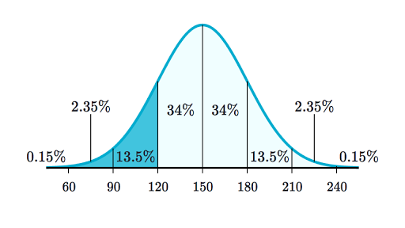

- A Normal distribution is completely specified by its mean and standard deviation. The “bell shape” doesn’t change.

## Summarizing Quantitative Data

If the data followed a Normal model,

- we would be justified in using the sample **mean** to describe the center, and
- in using the sample **standard deviation** to describe the spread (variation.)

But it is often the case that these measures aren’t robust enough, because the data show meaningful skew (asymmetry), or the data have lighter or heavier tails than a Normal model would predict.

## The Empirical Rule for Approximately Normal Distributions

If the data followed a Normal distribution,

- approximately 68% of the data would be within 1 SD of the mean,
- approximately 95% of the data would be within 2 SD of the mean, while
- essentially all (99.7%) of the data would be within 3 SD of the mean.

## Empirical Rule & Pulse Rates

```r
dat2 <- surv15 |> filter(complete.cases(pulse))

dat2 |> select(pulse) |> describe_distribution()
```

```
Variable |  Mean |    SD | IQR |           Range | Skewness | Kurtosis |   n | n_Missing
----------------------------------------------------------------------------------------
pulse    | 74.02 | 12.70 |  15 | [20.00, 124.00] |     0.14 |     0.80 | 577 |         0
```

Since 2014, we’ve had pulse rates on 577 students, with mean 74 beats per minute and standard deviation 12.7 bpm.

Consider a picture of the data…

## Histogram of 2014-2025 Pulse Rates

```r
dat2 <- surv15 |> filter(complete.cases(pulse))

ggplot(data = dat2, aes(x = pulse)) +
    geom_histogram(fill = "tomato", col = "white", binwidth = 5) +
    labs(title = "Pulse Rates of Dr. Love's students",
         subtitle = "2014-2025 (n = 577 students)",
         y = "Number of Students", x = "Pulse Rate (bpm)")
```

- Why might I have changed from specifying `bins` to `binwidth` here?
- Does the resulting plot look like a (bell-shaped) Normal distribution?

## Histogram of 2014-2025 Pulse Rates

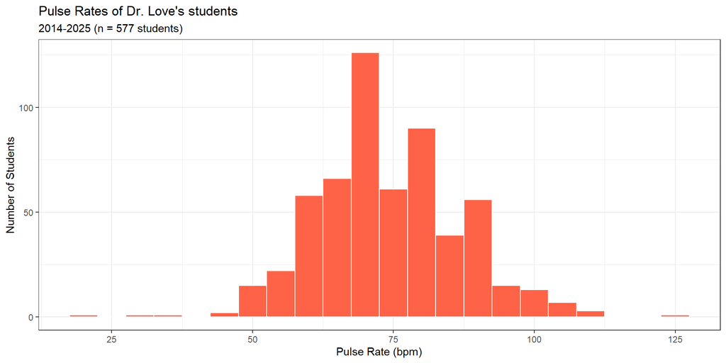

## Checking the 1-SD Empirical Rule

- Of the 577 pulse rates, how many were within 1 SD of the mean?
  - Mean = 74, SD = 12.7.
  - 74 - 12.7 = 61.3 bpm; 74 + 12.7 = 86.7 bpm

```r
surv15 |>
  filter(complete.cases(pulse)) |>
  count(pulse >= 61.3 & pulse <= 86.7)
```

```
# A tibble: 2 × 2
  `pulse >= 61.3 & pulse <= 86.7`     n
  <lgl>                           <int>
1 FALSE                             184
2 TRUE                              393
```

```r
393/(393+184)
```

```
[1] 0.6811092
```

## 2-SD Empirical Rule

- How many of the 577 `pulse` values were between 74 - 2(12.7) = 48.6 and 74 + 2(12.7) = 99.4 bpm?

```r
surv15 |> filter(complete.cases(pulse)) |>
    count(pulse >= 48.6 & pulse <= 99.4)
```

```
# A tibble: 2 × 2
  `pulse >= 48.6 & pulse <= 99.4`     n
  <lgl>                           <int>
1 FALSE                              28
2 TRUE                              549
```

```r
549/(549+28)
```

```
[1] 0.9514731
```

## 3-SD Empirical Rule

- How many of the 577 `pulse` values were between 74 - 3(12.7) = 35.9 and 74 + 3(12.7) = 112.1 bpm?

```r
surv15 |> filter(complete.cases(pulse)) |>
    count(pulse >= 35.9 & pulse <= 112.1)
```

```
# A tibble: 2 × 2
  `pulse >= 35.9 & pulse <= 112.1`     n
  <lgl>                            <int>
1 FALSE                                4
2 TRUE                               573
```

```r
573/(573+4)
```

```
[1] 0.9930676
```

## Histogram of 2014-2025 Haircut Prices

```r
dat3 <- surv15 |> filter(complete.cases(haircut))

ggplot(data = dat3, aes(x = haircut)) +
    geom_histogram(fill = "forestgreen", col = "white", bins = 20) +
    labs(title = "Haircut Prices of Dr. Love's students",
         subtitle = "2014-2025 (n = 644 students)",
         y = "Number of Students", x = "Haircut Price (USD)")
```

## Histogram of 2014-2025 Haircut Prices

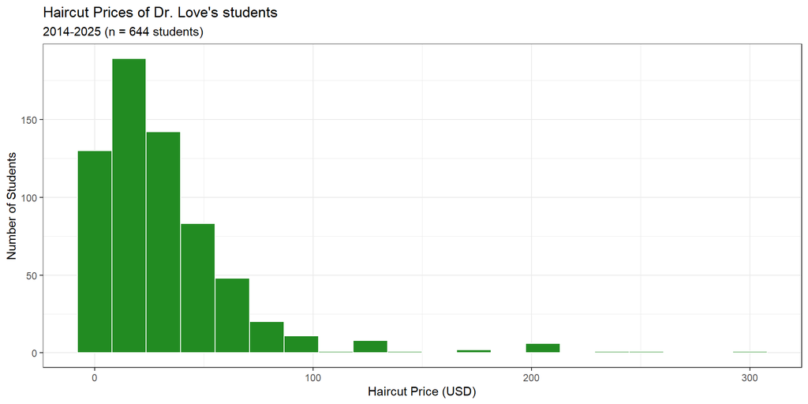

## Empirical Rule Table for 2014-2025 data

- $\bar{x}$ = sample mean, $s$ = sample SD
- For `pulse`: $n$ = 577 with data, $\bar{x} = 74, s = 12.7$
- For `haircut`: $n$ = 644 with data, $\bar{x} = 32.0, s = 35.2$

| Range | “Normal” | `pulse` | `haircut` |
| --- | --- | --- | --- |
| $\bar{x} \pm s$ | ~68% | $\frac{393}{577}$ = 68.1% | $\frac{581}{644}$ = 90.2% |
| $\bar{x} \pm 2\times s$ | ~95% | $\frac{549}{577}$ = 95.1% | $\frac{623}{644}$ = 96.7% |
| $\bar{x} \pm 3\times s$ | ~99.7% | $\frac{573}{577}$ = 99.3% | $\frac{632}{644}$ = 98.1% |

## Boxplots: Pulse Rate & Haircut Price

```r
dat2 <- surv15 |> filter(complete.cases(pulse))

p2 <- ggplot(data = dat2, aes(x = "pulse (bpm)", y = pulse)) +
  geom_violin() + geom_boxplot(width = 0.3, fill = "tomato") +
  labs(title = "Boxplot of Student Pulse Rates", x = "")

dat3 <- surv15 |> filter(complete.cases(haircut))

p3 <- ggplot(data = dat3, aes(x = "haircut ($)", y = haircut)) +
  geom_violin() + geom_boxplot(width = 0.3, fill = "forestgreen") +
  labs(title = "Boxplot of Student Haircut Prices", x = "")

p2 + p3 +
  plot_annotation(title = "15-Question Survey Data",
                  subtitle = "2014-2025 Students in 431")
```

- What is `width = 0.3` doing? How about the `x` options?
- What am I doing with `p2 + p3 + plot_annotation`?

## Boxplots: Pulse Rate & Haircut Price

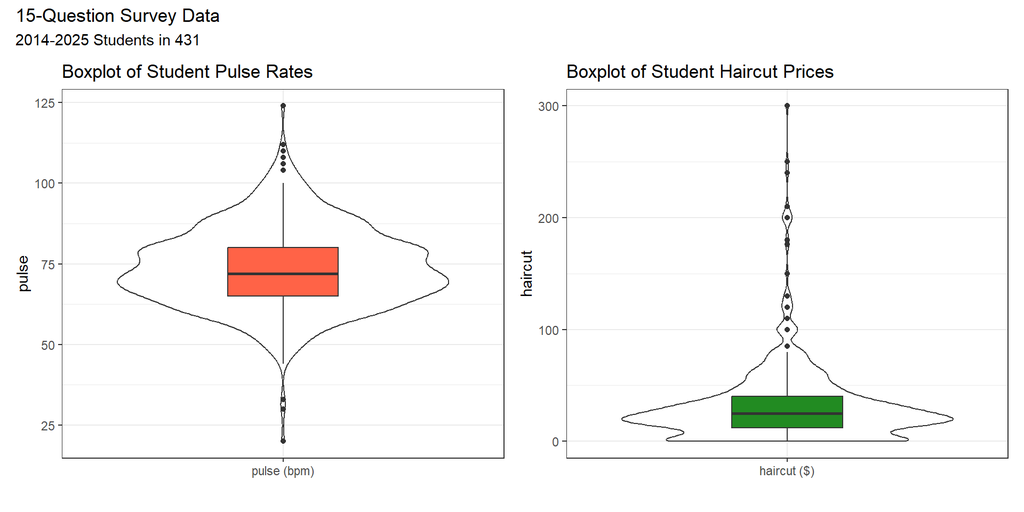

## Summarizing these data

- Normal distribution may be a reasonable model for `pulse` but not `haircut` according to our plots.

```r
surv15 |> reframe(lovedist(pulse))
```

```
# A tibble: 1 × 10
      n  miss  mean    sd   med   mad   min   q25   q75   max
  <int> <int> <dbl> <dbl> <dbl> <dbl> <dbl> <dbl> <dbl> <dbl>
1   656    79  74.0  12.7    72  11.9    20    65    80   124
```

```r
surv15 |> reframe(lovedist(haircut))
```

```
# A tibble: 1 × 10
      n  miss  mean    sd   med   mad   min   q25   q75   max
  <int> <int> <dbl> <dbl> <dbl> <dbl> <dbl> <dbl> <dbl> <dbl>
1   656    12  32.0  35.2    25  22.2     0    12    40   300
```

- What does these results imply about how we should summarize the data?

## Mean/SD vs. Median/MAD

If the data are approximately Normally distributed (like `pulse`) we can safely use the sample mean and standard deviation as summaries. If not (see `haircut`), then …

- The median is a more robust summary of the center.
- For spread, try the median absolute deviation<sup>1</sup>.

| Measure | observed | NA | Mean | SD | Median | MAD |
| --- | --- | --- | --- | --- | --- | --- |
| `pulse` | 577 | 79 | 74 | 12.7 | 72 | 11.9 |
| `haircut` | 644 | 12 | 32 | 35.2 | 25 | 22.2 |

[^1]: MAD scaled here to equal the standard deviation when data follow the Normal.

## Making Estimates from our Sample

One estimate of the average pulse rate of all students who study at CWRU could come from our sample.

```r
dat2 <- surv15 |> filter(complete.cases(pulse))

dat2 |> reframe(lovedist(pulse))
```

```
# A tibble: 1 × 10
      n  miss  mean    sd   med   mad   min   q25   q75   max
  <int> <int> <dbl> <dbl> <dbl> <dbl> <dbl> <dbl> <dbl> <dbl>
1   577     0  74.0  12.7    72  11.9    20    65    80   124
```

Our **point estimate** for the mean pulse rate of the population of all CWRU students is the mean from our sample of 577 students with known pulse rates: 74 bpm.

- How much uncertainty is there in that estimate?

## Uncertainty Interval for a Mean

A linear model (using only an intercept term) yields a 90% uncertainty (confidence) interval for the population mean.

```r
mod_pulse <- lm(pulse ~ 1, data = dat2)

model_parameters(mod_pulse, ci = 0.90)
```

```
Parameter   | Coefficient |   SE |         90% CI | t(576) |      p
-------------------------------------------------------------------
(Intercept) |       74.02 | 0.53 | [73.15, 74.89] | 140.04 | < .001
```

```
Uncertainty intervals (equal-tailed) and p-values (two-tailed) computed
  using a Wald t-distribution approximation.
```

Our 90% uncertainty interval (confidence interval) is (73.15, 74.89) beats per minute for the mean pulse rate across the entire population of CWRU students.

## A Bayesian estimate

Bayesian linear model (using only an intercept term) to obtain a 90% uncertainty (credible) interval for the population mean using a weakly informative prior.

```r
set.seed(4312025)
mod_pulse <- stan_glm(pulse ~ 1, data = dat2, refresh = 0)
model_parameters(mod_pulse, ci = 0.90)
```

```
Parameter   | Median |         90% CI |   pd |  Rhat |  ESS |                   Prior
-------------------------------------------------------------------------------------
(Intercept) |  74.02 | [73.12, 74.89] | 100% | 1.000 | 2797 | Normal (74.02 +- 31.74)
```

```
Uncertainty intervals (equal-tailed) computed using a MCMC distribution
  approximation.
```

90% credible interval (73.12, 74.89) is similar to 90% confidence interval (73.15, 74.89).

## Haircut Prices

A problem with the haircut price data is that it doesn’t follow a Normal distribution, so it’s more difficult to describe the center of the data with a sample mean…

```r
dat3 <- surv15 |> filter(complete.cases(haircut))
mod_haircut <- lm(haircut ~ 1, data = dat3)
model_parameters(mod_haircut, ci = 0.9)
```

```
Parameter   | Coefficient |   SE |         90% CI | t(643) |      p
-------------------------------------------------------------------
(Intercept) |       32.04 | 1.39 | [29.75, 34.33] |  23.08 | < .001
```

```
Uncertainty intervals (equal-tailed) and p-values (two-tailed) computed
  using a Wald t-distribution approximation.
```

- Is this a completely reasonable approach here?

# Question 4

## Question 4

Do tall people pay less for haircuts?

- Why might we think that they do, before we see the data?
- Convert our student heights from inches to centimeters…

```r
surv15 <- surv15 |> mutate(height_cm = height_in * 2.54)

surv15 |> select(student, height_in, height_cm) |> head()
```

```
# A tibble: 6 × 3
  student height_in height_cm
  <chr>       <dbl>     <dbl>
1 202501         63      160.
2 202502         68      173.
3 202503         75      190.
4 202504         62      157.
5 202505         64      163.
6 202506         71      180.
```

## A First Scatterplot

- We’ll include the straight line from a linear model, in red.

```r
dat4 <- surv15 |> filter(complete.cases(height_cm, haircut))

ggplot(dat4, aes(x = height_cm, y = haircut)) +
    geom_point(alpha = 0.3) +
    geom_smooth(method = "lm", col = "red",
                formula = y ~ x, se = TRUE) +
    labs(x = "Height (in cm)",
         y = "Price of last haircut (in $)",
         title = "Do taller people pay less for haircuts?")
```

## A First Scatterplot

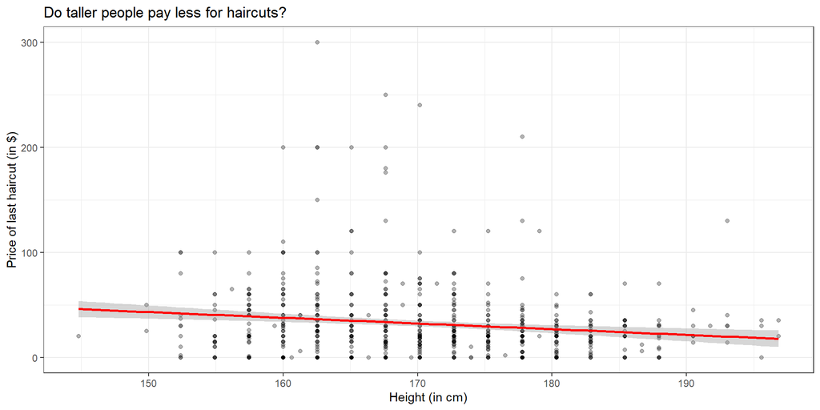

## Straight line regression model?

```r
dat4 <- surv15 |> filter(complete.cases(height_cm, haircut))

mod4 <- lm(haircut ~ height_cm, data = dat4)

mod4
```

```
Call:
lm(formula = haircut ~ height_cm, data = dat4)

Coefficients:
(Intercept)    height_cm
   124.5312      -0.5423
```

## Summarizing our model

```r
model_parameters(mod4)
```

```
Parameter   | Coefficient |    SE |          95% CI | t(640) |      p
---------------------------------------------------------------------
(Intercept) |      124.53 | 24.36 | [76.70, 172.36] |   5.11 | < .001
height cm   |       -0.54 |  0.14 | [-0.82,  -0.26] |  -3.80 | < .001
```

Regression Equation is:

$$haircut = 124.53 - 0.54 (height_{cm}) + error$$

Our predicted `haircut` price for someone who is 170 cm (about 5 feet 7 inches) tall is…

$$haircut = 124.53 - 0.54 (170) = $32.73$$

## Interpreting the Regression Equation

$$haircut = 124.53 - 0.54 (height_{cm}) + error$$

- The **intercept** suggests that a student who is 0 cm tall has an average haircut price of $124.53, although we don’t have any students in the data whose height is anywhere near as small as 0 cm, so this isn’t very useful.
- The **slope** is more important. When comparing two students who differ by 1 cm in height, we observe a haircut price that is, on average, $0.54 smaller for the student with the larger (taller) height.

## `lm` fit vs. `loess` smooth curve?

```r
dat4 <- surv15 |> filter(complete.cases(height_cm, haircut))

ggplot(dat4, aes(x = height_cm, y = haircut)) +
    geom_point(alpha = 0.5) +
    geom_smooth(method = "lm", col = "red",
                formula = y ~ x, se = FALSE) +
    geom_smooth(method = "loess", col = "blue",
                formula = y ~ x, se = FALSE) +
    labs(x = "Height (in cm)",
         y = "Price of last haircut (in $)",
         title = "Do taller people pay less for haircuts?")
```

- Does a linear model appear to fit these data well?
- Do taller people pay less for their haircuts?

## `lm` fit vs. `loess` smooth curve?

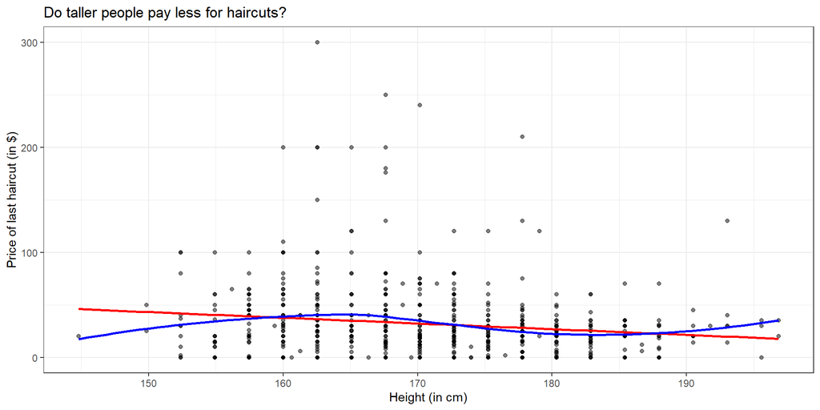

## What is the (Pearson) correlation of height and haircut price?

```r
dat4 <- surv15 |> filter(complete.cases(height_cm, haircut))

dat4 |>
    select(height_in, height_cm, haircut) |>
    cor()
```

```
           height_in  height_cm    haircut
height_in  1.0000000  1.0000000 -0.1486261
height_cm  1.0000000  1.0000000 -0.1486261
haircut   -0.1486261 -0.1486261  1.0000000
```

# Question 5

## Question 5

Do students have a more substantial tobacco history if they prefer to speak English or a language other than English?

```r
surv15 |> count(english, smoke)
```

```
# A tibble: 9 × 3
  english smoke     n
  <fct>   <fct> <int>
1 n       1       128
2 n       2         4
3 n       3         6
4 y       1       471
5 y       2        32
6 y       3         7
7 y       <NA>      1
8 <NA>    1         6
9 <NA>    <NA>      1
```

`smoke` codes (tobacco use): 1 = Never, 2 = Former, 3 = Current

## Restrict ourselves to 2025 data

- Do students in the 2025 class have a more substantial history of tobacco use if they prefer to speak a language other than English?

```r
dat5 <- surv15 |>
    filter(year == "2025") |>
    filter(complete.cases(english, smoke)) |>
    select(student, year, english, smoke)
summary(dat5)
```

```
   student               year    english smoke
 Length:53          2025   :53   n:15    1:47
 Class :character   2014   : 0   y:38    2: 3
 Mode  :character   2015   : 0           3: 3
                    2016   : 0
                    2017   : 0
                    2018   : 0
                    (Other): 0
```

## Tabulating the categorical variables individually

```r
dat5 |> tabyl(english)
```

```
 english  n   percent
       n 15 0.2830189
       y 38 0.7169811
```

```r
dat5 |> tabyl(smoke) |> adorn_pct_formatting()
```

```
 smoke  n percent
     1 47   88.7%
     2  3    5.7%
     3  3    5.7%
```

- What does `adorn_pct_formatting()` do?

## Cross-Classification (2 rows $\times$ 3 columns)

```r
dat5 |> tabyl(english, smoke)
```

```
 english  1 2 3
       n 12 1 2
       y 35 2 1
```

## Recode the `smoke` levels to more meaningful names in `tobacco`

```r
dat5 <- dat5 |>
    mutate(tobacco = fct_recode(smoke,
            "Never" = "1", "Quit" = "2", "Current" = "3"))
```

### Check our work?

```r
dat5 |> count(smoke, tobacco)
```

```
# A tibble: 3 × 3
  smoke tobacco     n
  <fct> <fct>   <int>
1 1     Never      47
2 2     Quit        3
3 3     Current     3
```

- Everyone with `smoke` = 1 has `tobacco` as Never, etc.

## Restate the cross-tabulation

Now we’ll use this new variable, and this time, add row and column totals.

```r
dat5 |> tabyl(english, tobacco) |>
    adorn_totals(where = c("row", "col"))
```

```
 english Never Quit Current Total
       n    12    1       2    15
       y    35    2       1    38
   Total    47    3       3    53
```

- What can we conclude about this association?

## How about in 2014-2025?

```r
dat6 <- surv15 |>
  filter(complete.cases(english, smoke)) |>
  mutate(tobacco = fct_recode(smoke,
            "Never" = "1", "Quit" = "2", "Current" = "3"))

dat6 |>
  tabyl(english, tobacco) |>
  adorn_totals(where = c("row", "col"))
```

```
 english Never Quit Current Total
       n   128    4       6   138
       y   471   32       7   510
   Total   599   36      13   648
```

- Now, what is your conclusion?

## Next Time

Working with a new data set

**Note**

By now, I’ve shown you everything you need to complete all Tasks for Lab 1, due next Wednesday at noon (2025-09-17.)